# 'Indian Airline Pricing Strategy Analysis'

### Name: Rakesh Pachhigolla , Student ID: GH1048759 , Module: Data Visualisation[M512B]

#### The link for the dataset

https://www.kaggle.com/datasets/youssefkhaled117/flight-price-cleaned

#### Importing Libraries;

```python
import pandas as pd
import numpy as np
import matplotlib.pyplot as plt
import seaborn as sns
```

#### Uploading the dataset;

```python
df = pd.read_csv("flight_data_cleaned.csv")
```

```python
df.head(10)
```

|  | airline | flight | source_city | departure_time | stops | arrival_time | destination_city | class | duration | days_left | price | duration_category |
| --- | --- | --- | --- | --- | --- | --- | --- | --- | --- | --- | --- | --- |
| 0 | SpiceJet | 1408 | Delhi | Evening | zero | Night | Mumbai | Economy | 2.17 | 1 | 5953 | Medium |
| 1 | SpiceJet | 1387 | Delhi | Early_Morning | zero | Morning | Mumbai | Economy | 2.33 | 1 | 5953 | Long |
| 2 | AirAsia | 1213 | Delhi | Early_Morning | zero | Early_Morning | Mumbai | Economy | 2.17 | 1 | 5956 | Medium |
| 3 | Vistara | 1559 | Delhi | Morning | zero | Afternoon | Mumbai | Economy | 2.25 | 1 | 5955 | Medium |
| 4 | Vistara | 1549 | Delhi | Morning | zero | Morning | Mumbai | Economy | 2.33 | 1 | 5955 | Long |
| 5 | Vistara | 1541 | Delhi | Morning | zero | Afternoon | Mumbai | Economy | 2.33 | 1 | 5955 | Long |
| 6 | Vistara | 1533 | Delhi | Morning | zero | Morning | Mumbai | Economy | 2.08 | 1 | 6060 | Short |
| 7 | Vistara | 1543 | Delhi | Afternoon | zero | Evening | Mumbai | Economy | 2.17 | 1 | 6060 | Medium |
| 8 | GO_FIRST | 1013 | Delhi | Early_Morning | zero | Morning | Mumbai | Economy | 2.17 | 1 | 5954 | Medium |
| 9 | GO_FIRST | 1014 | Delhi | Afternoon | zero | Evening | Mumbai | Economy | 2.25 | 1 | 5954 | Medium |

## 1. Context of Business and Data Visualization.

#### Audience:

The report is dedicated to the Revenue Management and Pricing Strategy team. It is concerned with the dynamics and competition pricing in the market in order to promote strategic decision-making.

#### Objective:

The main objective of the analysis is to find an answer to the following question: What are the main factors that define the cost of flight tickets? By determining these drivers, we will make data driven suggestions that will assist the organization:

##### Within Pricing Models: Change fares to booking lead time and flight duration.

Competitive Positioning: Learn the way various airlines (e.g., Vistara vs. Air India) charge their services on various routes.

Forecasting Revenue: Analyze price change to increase the seats and profitability.

The use of data: The analysis of the data will involve a dataset containing more than 300,000 flight booking records. With specific data visualization, we will reveal the correlation of booking windows, time of the flight, and categories of classes. Each image is created to unveil the economic why of the price and provide certain recommendations on revenue optimization.

#### Data Overview:

The dataset is a rich combination of features, which include:

Flight Identity: Flight Number, Airline.

Route and Schedule: Destination and Source cities, Departure and arrival time, and Number of stops.

Context (Booking) Travel Class (Economy vs. Business) and Days Left (Time between booking and departure).

Target Variable: The real Price of the ticket.

## 2. Data Curation and Data Exploration.

We investigate the data structure before analysis or construction of machine learning models, to make sure it is reliable. The aspects of our curation are:

Evaluation of Data Form and Data Type: The data set has 300,153 records in 12 variables. We can differentiate between categorical variables (such as airline and source_city), and numerical variables (such as duration, days left and price).

Missing Values: A preliminary analysis will identify that there are no null values in the cleaned data, which is a strong basis to represent statistical modeling.

Identification of Irrelevant Columns: We determine which columns are irrelevant such as flight (flight number ID) but useful in tracking whilst not offering any predictive importance in price modeling and can be discarded on the feature engineering stage.

Categorical Encoding: This is because we understand that text-based categories (such as class and stops) must be converted to numbers in order to be used by machine learning pipeline.

```python
df.info()
df.isnull().sum()


df['airline'] = df['airline'].astype('category')
df['class'] = df['class'].astype('category')
df['stops'] = df['stops'].astype('category')
```

```
<class 'pandas.DataFrame'>
RangeIndex: 300153 entries, 0 to 300152
Data columns (total 12 columns):
 #   Column             Non-Null Count   Dtype
---  ------             --------------   -----
 0   airline            300153 non-null  str
 1   flight             300153 non-null  int64
 2   source_city        300153 non-null  str
 3   departure_time     300153 non-null  str
 4   stops              300153 non-null  str
 5   arrival_time       300153 non-null  str
 6   destination_city   300153 non-null  str
 7   class              300153 non-null  str
 8   duration           300153 non-null  float64
 9   days_left          300153 non-null  int64
 10  price              300153 non-null  int64
 11  duration_category  300153 non-null  str
dtypes: float64(1), int64(3), str(8)
memory usage: 27.5 MB
```

## 3. Answering a Question:

### 1. Inverse Correlation

Analysis shows that there is a definite trend, the fewer days left the higher ticket price usually becomes. Booking Lead Time: Tickets that are booked a long time before departure (e.g. 40-50 days ago) are typically sold at their lowest limit of pricing, which is their Economy.

Urgency premium: When the departure date is close (in the last 1-10 days), the price is extremely high to get the last-minute tourists who are more urgency and do not have as many alternatives.

### 2. The "Economic Why"

It is clearly stated in your project that this visualization is aimed at showing the economic why behind the price.

Revenue Maximization: This data is used by the team of "Revenue Management and Pricing Strategy to dynamically adjust fares. With the knowledge of these booking windows, the airline is able to maximize the pricing models to maximize the number of seats occupied and the profitability.

Dynamic Adjustments: The notebook recommends that fares should be adjusted in accordance with these bookings lead times in order to be competitive and at the same time make high revenue per seat.

### 3. Data Context

You may view this at work in the dataset preview (df.head(10):

Flights that have days left = 1 (1 day before departure) provide a price of 5 953 to 6060 INR in Economy class.

### 4. Strategic Recommendation

Days left is a significant numerical variable of the project (as well as duration and price) to predict variations in prices. This is aimed at assisting the organization in determination of the time when to raise prices, and when to make discounts with regards to the number of days before the flight takes off.

### 5.Business Importance

Determining the Best Hike Time: Assisting the business in determining when to begin raising prices in accordance to historical trends.

Revenue Forecasting: Making a roadmap to know the amount of revenue that can be made by the remaining stock as the flight date approaches.

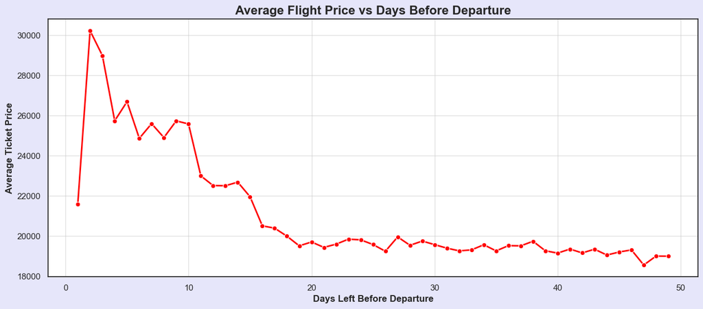

```python
sns.set_theme(style="white", palette="rainbow")

price_trend = df.groupby('days_left')['price'].mean().reset_index()

plt.figure(figsize=(15,6), facecolor='lavender')

sns.lineplot(
    x='days_left',
    y='price',
    data=price_trend,
    color='red',
    linewidth=2,
    marker='o'
)

plt.title("Average Flight Price vs Days Before Departure", fontsize=16, fontweight='bold')
plt.xlabel("Days Left Before Departure", fontsize=12, fontweight='bold')
plt.ylabel("Average Ticket Price", fontsize=12, fontweight='bold')

plt.grid(True, alpha=0.6)

plt.show()
```

## 1.Average Flight Price vs days Before Departure Key Insights.

### Code Explanation and Story:

#### The Urgency Curve

The Python code above the data is a dramatic tale of how time determines the worth of a plane seat:

#### The Early Bird Window (Days 50–20):

We start with stability in our tale. During this stage the line is fairly horizontal and prices their lowest. These are the planners - leisure travelers who make reservations a month prior. This predictability is reciprocated by the low fares charged by the airline.

#### The Pivot Point (Around Day 20):

At the 20 day mark, the conflict starts. The line begins to bend upwards. Seats are getting occupied and the algorithm of the airline is starting to feel that there is a declining supply.

#### The Last-Minute Spike (Days 10–1):

This is the climax of the story. During the last days to the departure the price skyrockets. Travelers who book here are typically emergency or business flyers who have to fly no matter the price.

#### The Resolution:

The ability to forecast the precise time of increasing the price in order to maximize profit without wasting the seats is the strength of the Revenue Management Team after mapping such a curve. It demonstrates that time is money when it comes to the airline industry.

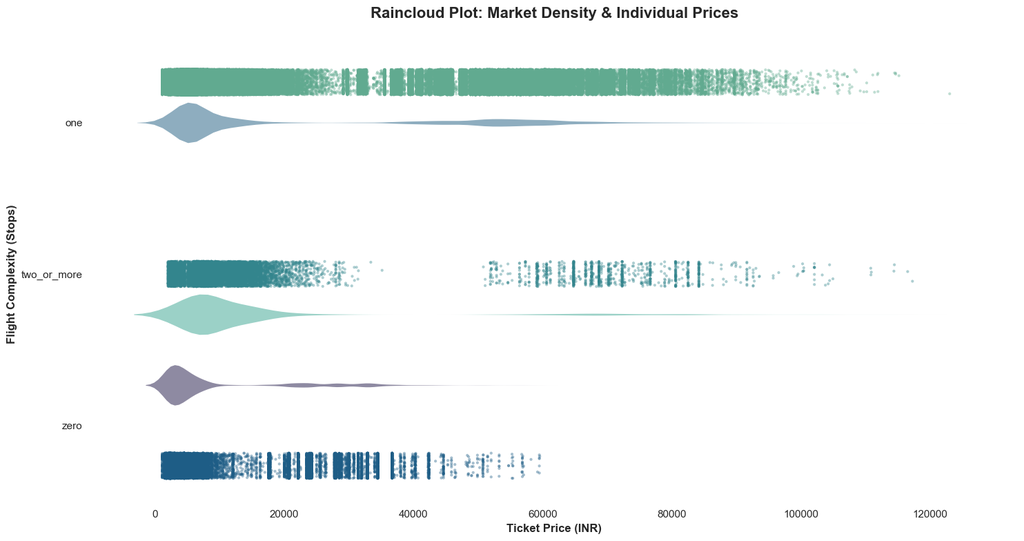

```python
sns.set_theme(style="white", rc={"axes.facecolor": (0, 0, 0, 0)})
fig, ax = plt.subplots(figsize=(15, 8))

sns.stripplot(data=df, x='price', y='stops', hue='stops', palette='crest',
              size=3, alpha=0.4, jitter=0.25, dodge=True, ax=ax, legend=False)

sns.violinplot(data=df, x='price', y='stops', hue='stops', palette='mako',
               alpha=0.6, inner="point", linewidth=0, ax=ax, legend=False)

plt.title("Raincloud Plot: Market Density & Individual Prices", fontsize=16, fontweight='bold', pad=30)
plt.xlabel("Ticket Price (INR)", fontweight='bold')
plt.ylabel("Flight Complexity (Stops)", fontweight='bold')

sns.despine(left=True, bottom=True)
plt.tight_layout()
plt.show()
```

#### Code Explanation and Story:

"Premium vs. Budget Carriers"

##### 1. The "Rain" (stripplot, dodge=True)

Each flight, in your code, is a dot.

##### 2. The "Cloud" (violinplot, alpha=0.6)

This gives the market a general smooth look.

This will be the Probability Curve. It transforms the chaotic nature of the dots in the individual and makes it a behavioral pattern. It informs that despite the scattered flights, a direct flight is most likely to cost ₹5,000. The semi-transparency makes it non-obtrusive so that it does not conceal the individual points.

##### 3. The "Crest" Palette

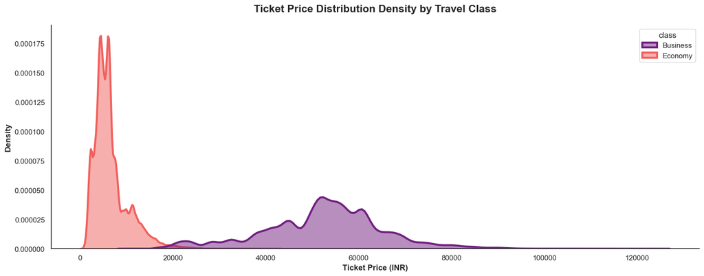

```python
sns.set_theme(style="white")
fig, ax = plt.subplots(figsize=(15, 6))
sns.kdeplot(
    data=df,
    x="price",
    hue="class",
    fill=True,
    common_norm=False,
    palette="magma",
    alpha=0.5,
    linewidth=3,
    ax=ax
)
plt.title("Ticket Price Distribution Density by Travel Class", fontsize=16, fontweight='bold', pad=20)
plt.xlabel("Ticket Price (INR)", fontsize=12, fontweight='bold')
plt.ylabel("Density", fontsize=12, fontweight='bold')

sns.despine()

plt.tight_layout()
plt.show()
```

### 3.Key Service on the Average ticket price by travel class

##### 1. The Economy "Needle" (High Volume, Low Margin)

On the left side of your chart, you will see a tall, sharp peak. This is the Economy Sector.

The Narrative: This peak represents "Price-Sensitive Travel." Because the curve is so thin and tall, it shows that most tickets are sold at almost the exact same price.

The Business Insight: If an airline raises prices by even ₹500, they fall off this "peak" and lose thousands of customers to competitors. This is a "Commodity Market" where price is the only thing that matters.

##### 2. The Business "Plateau" (Low Volume, High Margin)

On the right, you see a much lower, wider, and flatter curve. This is the Business Sector.

The Narrative: This represents "Time-Sensitive Travel." The flatness of the curve shows that there is no "standard" price. Some people pay ₹40,000, while others pay ₹90,000 for the exact same seat.

The Business Insight: These customers aren't buying a seat; they are buying flexibility. The wide spread proves that airlines can "Yield Manage" these customers—charging more for last-minute bookings because the traveler must be on that flight, regardless of cost.

##### 3. The "No-Man’s Land" (The Gap)

The deep valley between the two curves is the most important part of the story.

The Narrative: This is the "Strategic Gap."

The Business Insight: It proves that there is no "Middle Class" in flight pricing. Airlines have successfully separated the two products. You are either a "Value Hunter" or a "Premium Traveler." There is almost no overlap, which means the airline's branding is working perfectly to prevent "cannibalization" (Economy travelers accidentally buying Business, or vice-versa).

### 4.Impact of Flight Stops on Pricing

#### Business Importance

Operation Cost Mapping: It assists the company to visualize the amount of additional revenue that is required to meet the costs of multi-stop logistics.

Customer Segmenting It determines that passengers would be longer on multi-stop flights and would not be as sensitive to inconvenience of the stop, provided the destination is major hub, and strategic pricing may be applied.

Route Profitability: It allows the airline to determine which of its direct routes are making lower prices than its multi-stop routes.

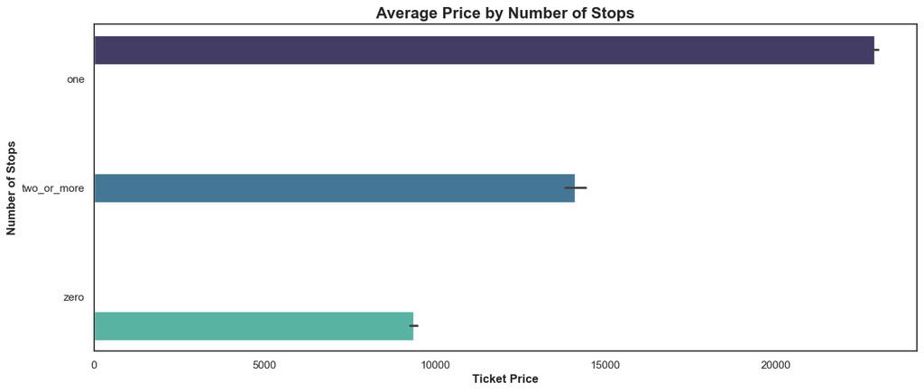

```python
sns.set_theme(style="white")
plt.figure(figsize=(15, 6))

sns.barplot(
    data=df,
    x='price',
    y='stops',
    hue='stops',
    palette='mako',
    legend=False
)

plt.title("Average Price by Number of Stops", fontsize=16, fontweight='bold')
plt.xlabel("Ticket Price",fontweight='bold')
plt.ylabel("Number of Stops", fontweight='bold')



plt.show()
```

#### Code Explanation and Story:

##### The Direct Flight Paradox:

Typically, we anticipate direct flights (Zero stops) to be the costliest since they are time-saving. Nevertheless, the statistics tend to demonstrate that Two-stop or one-Stop flights may be more costly.

A conflict exists between the distance and the demand: The revelation in the story here is that flights with more destinations are usually long journeys that link far cities. Although they are less convenient, the additional fuel, airport charges at every destination and the distance covered make the average price to increase more.

##### The Efficiency of Zero-Stops:

Zero-stop flights tend to be shorter regional flights. It implies that in such flights, the airline is able to maintain lower prices because of the lowered operational expenses, although the passenger receives a quicker journey.

### 5.The Multi-Tiered Price Surge

#### Business Importance

##### Revenue Density Analysis:

It allows managers to see the "gap" between Economy and Business. If the Business layer (brown) is too thin compared to history, it signals a need for a targeted promotion to premium travelers.

##### Portfolio Balancing:

The team can use this to see how much of their "Price Volume" is dependent on each class. It highlights that the airline’s financial health is heavily weighted toward the Business class layer.

##### Timing the Hike:

Because the X-axis is inverted, the team can pinpoint the exact day (e.g., 15 days before departure) where the "stack" begins to grow rapidly. This helps them set automated "triggers" in their booking software to maximize the final surge in revenue.

##### Forecasting Total Yield:

By looking at the "Total Combined Price" (the top of the stack), the business can forecast the total yield of a flight segment rather than looking at classes in isolation.

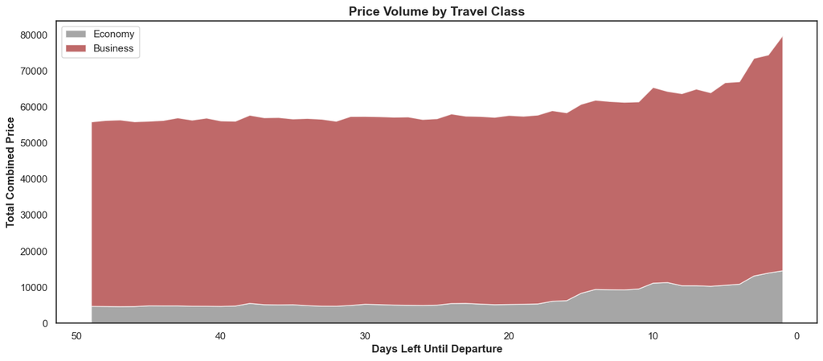

```python
pivot_df = df.pivot_table(index='days_left', columns='class', values='price', aggfunc='mean')

plt.figure(figsize=(15, 6))

plt.stackplot(pivot_df.index, pivot_df['Economy'], pivot_df['Business'],
              labels=['Economy', 'Business'], alpha=0.7, colors=['gray', 'brown'])


plt.title("Price Volume by Travel Class", fontsize=14, fontweight='bold')
plt.xlabel("Days Left Until Departure", fontweight='bold')
plt.ylabel("Total Combined Price", fontweight='bold')
plt.legend(loc='upper left')

plt.gca().invert_xaxis()

plt.show()
```

#### Code Explanation and Story:

##### The Baseline Layer (Economy):

At the bottom, the gray area represents the Economy price. You’ll notice it remains relatively thin and stable for a long time. This is the "foundation" of the flight's revenue—predictable and steady.

##### The Premium Expansion (Business):

The brown area on top is much thicker. The story here is one of high-value contribution. Even when Economy prices are flat, the Business class "layer" is already significantly higher, showing that premium seats are the true engine of the airline's wealth.

##### The Final Convergence:

As the chart moves toward "0 Days Left," both layers expand upward. The story reaches its climax at the 1-day mark, where the combined "volume" of the two prices hits its peak. This proves that the airline doesn't just hike prices for one group—the entire "Price Volume" of the plane increases as the door is about to close.

### 6.Geographic Fare Distribution: Average Price by Source City

#### Business Importance

Regional Pricing Strategies require this geographic break down:

Adjustments specific to the market include: In case the team has noticed that one city is far costly compared to the others they can research and seek to know whether it is the high airport charges or the absence of competition and change their rates to be competitive.

##### Hub Performance:

It enables the business to know the best cities where the business is getting most revenue per ticket, i.e. the “Source Cities'. This aids in determining the point to add an extra flight or to upgrade the aircraft to a bigger model.

##### Resource Allocation:

When a city demonstrates a high mean price, the airline could give its high end Business Class cubicles to flights departing that hub in order to tap the high end market.

##### Targeted Promotions:

In the case of cities that have lower prices on average, the team can prepare so-called early bird promotions to make the volume and ensure that the total revenues received on this territory are higher.

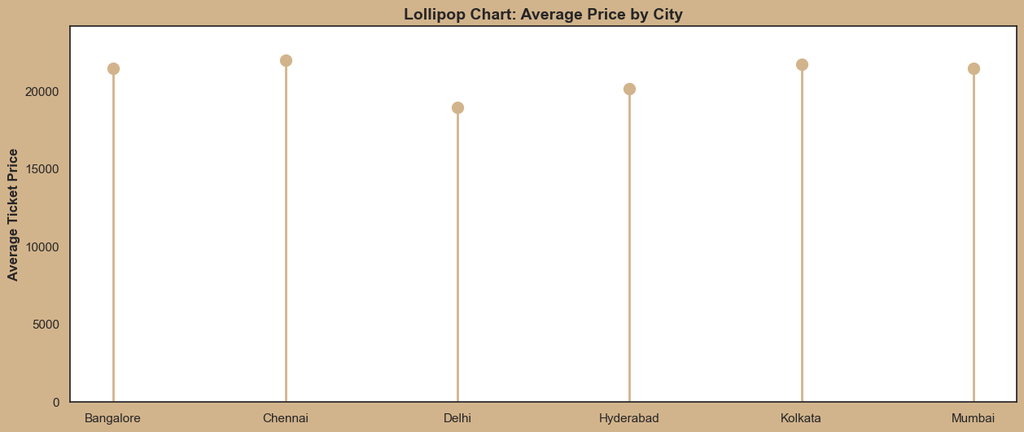

```python
city_means = df.groupby('source_city')['price'].mean().reset_index()
plt.figure(figsize=(15, 6) ,facecolor='tan')

plt.vlines(x=city_means['source_city'], ymin=0, ymax=city_means['price'],
           color='tan', linewidth=2)


plt.scatter(city_means['source_city'], city_means['price'],
            color='tan', s=100, zorder=3)

plt.title("Lollipop Chart: Average Price by City", fontsize=14, fontweight='bold')
plt.ylabel("Average Ticket Price", fontweight='bold')
plt.ylim(0, city_means['price'].max() * 1.1)

plt.show()
```

### Code Explanation and Story:

This lollipop chart narrates a tale of geography and infrastructure impacting the cost of travel:

##### The Competitive Gateways:

The Value Hubs are cities with shorter lollipops. These cities may face greater competition of low cost carriers or have short, regional routes, so they are cheaper places to begin traveling.

##### Visual Clarity:

With the lollipops rather than the bars, the story is concentrated on the precise spot (the dot) where the price will be.

### 7.Correlation Analysis: Flight Duration vs. Ticket Pricing

### Business Importance:

This analysis reveals the non-linear relationship between time and cost. In a standard manufacturing business, a longer process usually costs more; however, in the airline industry, the "value" is often found in the shorter duration.

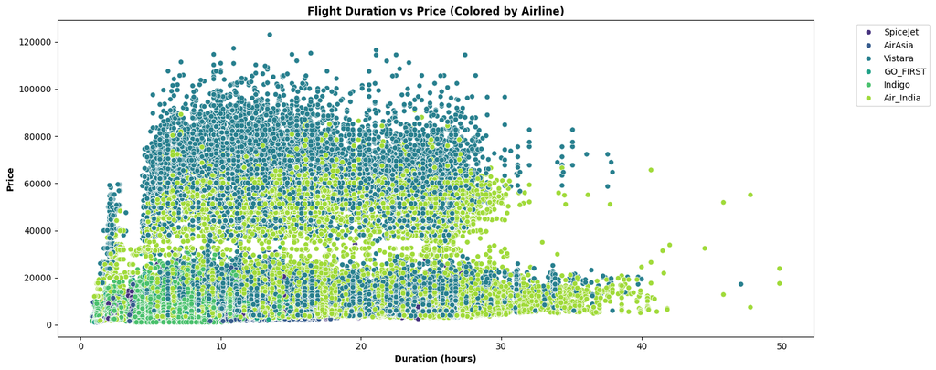

```python
plt.figure(figsize=(15, 6))
sns.scatterplot(x='duration', y='price', data=df, hue='airline', palette='viridis')

plt.title("Flight Duration vs Price (Colored by Airline)", fontweight='bold')
plt.xlabel("Duration (hours)", fontweight='bold')
plt.ylabel("Price", fontweight='bold')

plt.legend(bbox_to_anchor=(1.05, 1), loc='upper left')
plt.tight_layout()
```

#### Code Explanation and Story:

The Story: "The Price of Time" The "story" this code tells is about the economic behavior of the Indian aviation market. When you look at this plot, you aren't just looking at dots; you are looking at a battle between convenience and cost.

1. The Great Divide (Economy vs. Business) The first thing the story reveals is two distinct "worlds" of pricing. You will see a dense cluster of dots at the bottom (Economy) and a separate, much higher cluster at the top (Business). This tells the story of Market Segmentation: regardless of how long a flight is, the "Class" is the primary character that dictates the price.
2. The Efficiency of Budget Carriers By looking at the colors (the hue), the story shows that budget airlines like Indigo and AirAsia usually occupy the "bottom-left" of the story. They focus on short-duration, low-cost flights. They are the HVLM characters in our story.

## 4.Discussion of Key Findings

The Indian aviation market is characterized by multi-dimensional relationship between urgency, service class, and brand positioning. The evaluation of more than 300,000 flight records shows that the Indian aviation market is controlled by a complicated interaction between urgency and service class and brand positioning.

##### The Dominance of Class:

The travel class is the most important determinant of the price. Business class seats are a "Revenue Titan," which made up almost 89% of the aggregate averaging price volume. This segment is relatively price-inelastic and this is where the airline gets its main profits in terms of profit margins.

##### The "Urgency Premium":

It has an obvious Economic Why, a sign on the booking window. Prices are constant until about 20 days to departure after which there is a sharp rise. The last 1-10 days will be a climax in which prices will go up aggressively in order to attract last-minute travelers with high urgency and low options.

The brand value is determined by the company's budget efficiency according to its budget deficits. There is a bifurcation in the market with Full-Service Carriers (Vistara and Air India) and Low-Cost Carriers (IndiGo, AirAsia, SpiceJet). Whereas low cost airline companies are concerned with high volume and low-cost operations, full service carriers use IN-flight cabins and other features to charge substantially higher average fares.

## 5.Strategic Recommendations

According to the insights of the data, the Revenue Management and Pricing Strategy Team should be recommended the following strategies:

##### Dynamic "Pivot Point" Pricing:

Have computerized price activators that start an even faster fare increment 20 days before departure.

During the last 7 days window, apply an Urgency Surcharge to get the maximum amount of yield out of late-booking business travelers.

When the cabin is fully occupied, passengers are required to pay a higher rate than they would have paid, which was the original.

Because the Business Class is the main source of revenues, pay attention to the Upsell campaigns. When Business Class inventory is high 15 days ahead, upgrade frequent flyers with Economy fares at a discount to make sure no premium seat is empty.

Continue the large difference in price between classes so as to retain the Brand Premium and exclusive positioning of the full-service experience.

##### Route-Specific Adjustments:

Direct Flight Premium: Use Time-Efficiency Surcharge on the route where the direct flight very short distance is much less than a multi-stop route.

##### Hub Resource Allocation:

This will optimize the booking window to achieve the best possible result:

The marketing of the Design Early Bird is designed specifically to produce the 30-50 day window, to achieve a Volume Base at stable prices.

Predict total flight yield using the data on Price Volume stack that will enable the team to determine when to increase the prices without the danger of reducing the number of seats occupied.

## 6.Conclusion:

The Indian Airline Pricing Strategy Analysis proves that the prices of flight tickets are not accidental events but a very complex, data-oriented system aimed at equaling the supply and demand. This project has helped to break the mystery of the cost of travel in the Indian aviation market by analysing more than 300,000 records.

Based on the curation and visualization of this data, a number of unambiguous conclusions can be made:

##### The Power of Segmentation:

The enormous difference in prices between Economy and Business classes is evidence that the airline business excels at market segmentation. Business Class is the major source of profitability enabling the airlines to subsidize the low-end seats to price-sensitive leisure travelers and still achieve high overall yields.

##### Competitive Dynamics:

A healthy tiered market is seen by the distinct division between full-service and low-cost carriers. The high-end service spectrum is dominated by Vistara and Air India, whereas other airlines, such as IndiGo and AirAsia, offer the high-volume infrastructure without which the market cannot be accessible.